In this post we’re going to demonstrate the use of Bayesian hierarchical models to overcome the weak instruments problem. We essentially recreate the work of [Chamberlain and Imbens, 2003](https://doi.org/10.1111/j.1468-0262.2004.00485.x) which I definitely should have read *before* embarking on this project and not *after* - ah well, we live and learn. We’re going to fit a moderately complicated instrumental variables model in [stan](https://mc-stan.org/) along the way. The set-up is a little involved with this one, so feel free to skip straight to the results at the bottom - there are some pretty plots.

# Setting up The Problem

There’s a lot of material on weak instruments online so we’ll keep this short - a simple, canonical weak instrument problem looks something like this:

$$\begin{aligned}
\beta - \hat{\beta} &= (Z'X)^{-1}Z'\varepsilon \\
&\rightarrow (0)^{-1}(0)
\end{aligned}$$

Even asympotically as $N$ grows the first stage relationship effectively disappears. We can think of an instrument as an exogenous shock to one part of the system and in the weak instruments problem this shock is too small - we get a nasty limiting distribution.

Rephrasing the above along Mostly Harmless lines using the Wald estimator we have:

$$\begin{aligned}
y_i &= z_i\gamma + u_i \text{ (Reduced Form)}\\
x_i &= z_i\pi + e_i \text{ (First Stage)} \\ \\
\hat{\beta}_{iv} &= \frac{\hat{\gamma}}{\hat{\pi}}
\end{aligned}$$

How do we fix this? Well a good way would be to stop dividing by 0 - bad things tend to happen when we divide by 0.

# A Simple Bayesian Approach

Let’s embed the above in a Bayesian setting, focusing on the first stage for now:
$$\begin{aligned}
\pi &\sim N(\mu, \lambda^{-1} ) \\
X &= Z\pi + e \\
\pi_{\text{posterior}} &= (Z'Z + \lambda)^{-1}(Z'Z\hat{\pi} + \lambda\mu)
\end{aligned}$$

The first line indicates lays out our prior over $\pi$, we’ve used a precision parametrisation to make the interpretation of $\lambda$ easier. The second line just switches notation slightly towards a matrix algebra formulation. Finally, we come to the posterior.

The posterior of $\pi$ is very similar to the frequentist solution but we have this extra $\lambda$ term - the interpretation here is that the posterior is essentially a precision weighted average of our prior and the data where $\hat{\pi}$ is the least squares solution familiar to frequentists.

# How does this help us?

Well, we require $\pi_{\text{posterior}} \nrightarrow 0$ whilst $\hat{\pi} \rightarrow 0$. Therefore, we *really, really* want $\mu \nrightarrow 0$.

This gives us two potential solutions:

- Non-centred prior, $\pi \sim N(f(n)\times\mu, \lambda^{-1})$ where $\mu \neq 0$ (Don’t do this, please).
- **Bayesian Hierarchical model, $\hat{\mu}$ is a precision weighted average of $\hat{\pi}_j$ for all groups/levels across our data.**

Using a BHM:

$$\begin{aligned}
\mu \sim N(\hat{\mu}, \hat{V}_{\mu}) \\
\hat{\mu} = \frac{\sum^J\frac{\hat{\pi}_j}{\sigma^2_j + \lambda^2}}{\sum^J\frac{1}{\sigma^2_j + \lambda^2}}
\end{aligned}$$

Where $\sigma^2_j$ indicates the variance of the model’s “lower level” ($X_{ij} = Z_{ij}\pi_j + e_{ij};\ e_{ij} \sim N(0, \sigma^2_j)$).

Essentially, weak instrument groups are identified off the population mean which produces a sensible measure of underlying uncertainty in weak instrument groups. The population mean is a variance weighted average of each group’s parameter - if we see a strong signal from one group it has more weight in determining the overall population mean.

Weak instrument identification off the population mean is reflected in larger probability intervals for weaker groups, *however* the limiting distribution is well-behaved and *non-degenerate* unlike its frequentist cousin.

We’re going to focus building a model using the second bullet point in the rest of this post.

# Bayesian Hierarchical Model

The above brushed over what a Bayesian hierarchical model actually *does* - we’ll talk very briefly about the intuition here.

Suppose we observe multiple natural groups or levels in our data indexed by $j$ - maybe a treatment effect from a federal policy we observe across states or cities. In some states we might face a very weak instrument but in others a much stronger instrument. We know that what we learn from one treatment effect should probably generalise, to a degree, to another city. A Bayesian hierarchical model lets us put structure over this generalisability; we want to separate sampling variation from true heterogeneity in treatment effects; introduce regularisation through hierarchical shrinkage and overcome the weak instruments problem - a BHM brings all these good things to the table.

Sometimes a BHM is simplest to think about when we draw it, here $\beta_j$ indexes *groups* **not** *regressors*:

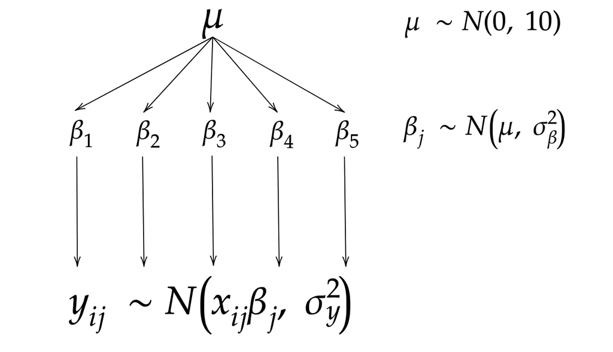

We model each group’s $\beta_j$ as being drawn from some underlying *population* or *global* parameter, $\mu$. We’re Bayesians so we put a prior probability distribution over $\mu$ - we call these *hyper*-priors, here $N(0, 10)$.

Typically in frequentist estimation we face two extremes when data is observed across multiple groups, for instance consider panel data:

- We can pool everything together and ignore heterogeneity across a dimension e.g. pooling all observations across time into one “cross-section”.
- Running a separate regression for each time period; we call this the no-pooling model.

Another alternative is to estimate a fixed effects regression - we estimate a dummy for each individual or time period or both. The fixed effects regression is sort of a half way house where we let an entity’s intercept vary but still maintain constant slopes across individuals.

The BHM represents a compromise between the two extremes - it can return the pooling or no-pooling estimate but also some weighted average between. The solution a BHM will return will depend on the *hierarchical variance* of the data; essentially we ask: how much of the difference in treatment effects is due to sampling variation vs true heterogeneity. As such, Bayesian hierarchical models are often fit with varying slopes and intercepts - not only are there additive differences between group outcomes but the treatment can have differential effects across groups.[^1]

But we’re not quite done - we want to perform instrumental variables estimation, not simple OLS. The solution - add another dimension:

$$\begin{aligned}
\mathcal{Y}_{j} &= (\textbf{Y}_{j} \quad \textbf{X}_j) \\
\mathcal{Y}_j &\sim MVN( \mathcal{X}_j \mathcal{B}_j, \Omega_j) \quad \forall i, j
\end{aligned}$$

where:

$$\begin{aligned}
\text{Y}_{ij} &= \widehat{\text{X}}^n_{ij}\beta_j^{iv} + X_{ij}^e\beta^{e}_j + u_{ij} \\
\text{X}_{ij} &= \text{Z}_{ij}\pi_j + X^e_{ij}\gamma_j + e_{ij}
\end{aligned}$$

Stacking into block matrices gives:
$$\begin{aligned}
(\textbf{Y}_j \quad \textbf{X}_{j}) &= (\text{Z}_{ij} \quad X^e_{ij}) \begin{pmatrix}
\pi_j \beta^{iv}_{j} & \pi_j \\
\gamma_j \beta^{iv}_j + \beta^e_j & \gamma_j
\end{pmatrix} \\
&= \mathcal{X}_j (\mathbf{b}^r \quad \mathbf{b}^f) \\
&= \mathcal{X}_j \mathcal{B}_j
\end{aligned}$$

We need to use the multivariate normal here to fully account for posterior uncertainty across both relationships. Modelling the problem as two independent normals is the Bayesian analogue to computing two-stage least squares manually and forgetting to adjust our standard errors.

Where the multivariate normal covariance matrix describes the first stage and reduced form’s variance and covariance:

$$\Omega_j = \begin{pmatrix}
\sigma^{2}_{r,j} & \sigma_{fr, j} \\
\sigma_{fr, j} & \sigma^{2}_{f, j}
\end{pmatrix}$$

## Priors

We need to put some priors on all of the above, here we use a pretty standard set up:

$$\begin{aligned}
\mathbf{b}^{d}_j &\sim MVN(\mu^{d}, \Sigma^d) & r, f \in d \\
\mu^{r}, \mu^{f} &\sim N(0, 10)
\end{aligned}$$

As is common in Bayesian estimation we split our covariance matrices up into a scale and correlation matrix:

$$\begin{aligned}
\Sigma &= \text{diag}(\tau) \Phi \text{diag}(\tau) \\
\Omega_j &= \text{diag}(\nu_j) \Theta_j \text{diag}(\nu_j)
\end{aligned}$$

with priors:

$$\begin{aligned}
\tau, \nu &\sim \text{Cauchy}^+(0, 5) \\
\Phi, \Theta_j &\sim \text{LKJ}(2)
\end{aligned}$$

That’s almost all the Greek alphabet I know, so fortunately we can turn to actually estimating this monster now.

## Sufficient Statistics

Unfortunately, fitting this model in stan would take a **long** time. Hierarchical models are notoriously hard to fit and we’re bumping the difficulty up somewhat by estimating a multivariate hierarchical model.

Fortunately, help is at hand - we’re using a multivariate normal likelihood which means we can exploit the fact that the normal is in the exponential family of distributions and therefore the factorisation criteria means we can find sufficient statistics for the normal likelihood. For the univariate case, suppose we’re estimating the mean of $n$ $x_i$ draws from a Gaussian distribution, rather than evaluating the likelihood conditioning on *all* the data we can just use $\sum^n_i{x_i}$ and $\sum^n_i{x_i^2}$ to evaluate the likelihood.

This is an incredible speed up for stan - rather than looping over $N$ data points we can loop over $J$ sets of sufficient statistics.

To move from the univariate to multivariate case we’re going to reparametrise the problem to create a residual matrix and compute $\bar{\mathbf{x}}$ and $\hat{\Sigma}$

Therefore, define a residual matrix:
$$R = (Y_{j} \quad X^n_j) - (Z_{j} \quad X^e_{j}) \begin{pmatrix}
\pi_j \beta^{iv}_{j} & \pi_j \\
\gamma_j \beta^{iv}_j + \beta^e_j & \gamma_j
\end{pmatrix} \\$$

For simplicity’s sake let’s rewrite this as:

$$R = (a - db)$$
Therefore we need to factor the likelihood:

$$L = (2\pi)^{\frac{-n}{2}}|\Sigma|^{-\frac{n}{2}}exp(-\frac{1}{2} R'\Sigma^{-1}R)$$

Into something like this:
$$\text{log} L \approx -\frac{n}{2}\Sigma^{-1}\bar{R'}\bar{R} - \frac{1}{2} \text{trace}(\Sigma^{-1}R'R)$$

I’m not sure this is the most elegant formulation but it was the easiest for me to debug in R.

Calculating $R'R$ (and the analogous $\bar{R'}\bar{R}$) is just a matter of expanding out $(a' - b'd')(a-db)$:

$$\begin{aligned}
R'R &= a'a - 2a'db + b'd'db \\
a'a &= \pmatrix{Y'Y \quad Y'X_n \\
X'_nY \quad X'_nX_n} \\
a'd &= \pmatrix{Y'Z \quad Y'X_e \\
X'_nZ \quad X'_nX_e} \\
d'd &= \pmatrix{Z'Z \quad Z'X_e \\
X'_eZ \quad X'_eX_e}
\end{aligned}$$

That’s the last of the algebra - I promise. It’s worth noting that the elements of each matrix are themselves block matrices, writing the sufficient statistics out in their most general format makes it easier to add multiple instruments and covariates later down the line.

# Generating Fake Data

First we’re going to define a function to generate our model coefficients. Here we’ve modelled our coefficients of interest, $\beta^{iv}_j$, as normal with mean 1 and variance 1. The first stage relationship of interest, $\pi_j$, will be centred at -2 with variance 1 also - however we’ve set $\pi_1 = 0$ for every draw of the simulation. Our exogenous variables are centred at 0, again with variance 1.

```r
create_betas <- function(J = 5){
  mu_iv <- 1
  mu_fs <- -2

  beta_iv <- rnorm(J, mu_iv, 1)
  beta_fs <- rnorm(J, mu_fs, 1)
  beta_exog <- rnorm(J, 0, 1)
  beta_fs[1] <- 0
  beta_fs
  return(list(
    beta_iv = beta_iv,
    beta_exog = beta_exog,
    beta_fs = beta_fs
  ))
}
```

Now we’re going to generate our $X, Z \text{ and } Y$ data:

```r
create_hier_iv_sim_data <- function(n = 1000,
                                    J = 5,
                                    beta_iv,
                                    beta_fs,
                                    beta_exog){


  z <- rnorm(n)
  confounder <- rnorm(n)
  x_exog <- rnorm(n)

  Sigma = matrix(c(5,2.5,2.5,5),2,2)
  ue = rmvnorm(n, rep(0,2), Sigma)

  x_endog <- ue[, 1] + confounder + beta_fs * z
  y <- beta_iv * x_endog +  confounder +  beta_exog * x_exog + ue[, 2]

  df <- data.frame(y,
                   x_endog,
                   z,
                   id = 1:J,
                   x_exog
                   )

  return(list(data = df,
              beta_iv = beta_iv,
              beta_fs = beta_fs,
              beta_exog = beta_exog))
}
```

In the above function we’ve created dependence across the errors in each equation by setting the covariance on the off diagonal to 2.5.

Now we create a function to actually fit the frequentist and Bayesian models - `hierarchical_iv_sufficient_statistics` just computes the SSs we derived above. We’ve set the `adapt_delta` argument to stan’s `sampling` extremely high - this model code was originally for a slightly different data generating process and re-parametrising the model just for this post is something I’d rather avoid. One of the advantages of sufficient statistics is that we can be lazy and often bruteforce divergent transitions through a higher adapt delta instead of non-centred parametrisation.

```r
fit_models <- function(sim_data, stan_model = hier_indep_model){

  # Calculating no pooling frequentist results using group_map
  freq_result <- sim_data$data %>%
    group_by(id) %>%
    group_map(~ivreg(data = ., y ~ x_endog + x_exog | z + x_exog ) %>% tidy(conf.int = TRUE)) %>%
    map_df(filter, term == "x_endog") %>%
    mutate(true_term = sim_data$beta_iv,
           fist_stage = sim_data$beta_fs,
           beta_exog = sim_data$beta_exog,
           model = "frequentist",
           j = sim_data$data %>% select(id) %>% unique() %>% pull())


  # Calculating sufficient statistics to pass to stan
  ss_stan <- hierarchical_iv_sufficient_statistics(sim_data$data,
                                                   "y",
                                                   "x_endog",
                                                   "x_exog",
                                                   "z",
                                                   "id")
  # Sampling from the model
  bhm_results <- sampling(
    stan_model,
    ss_stan,
    chains = 4,
    cores = 4,
    control = list(adapt_delta = 0.9999999999,
                   max_treedepth = 15)
  )

  # Computing posterior medians
  model_draws <-   bhm_results %>%
    gather_draws(beta_iv[j, k]) %>%
    median_qi() %>%
    to_broom_names() %>%
    ungroup() %>%
    mutate(true_term = sim_data$beta_iv,
           model = "BHM")
  # Combining results across models
  both_draws <- bind_rows(
    model_draws,
    freq_result
  )
  # Returning model results and stan object for debugging
  return(list(both_draws = both_draws,
              bhm_model = bhm_results))

}
```

Next up, is the stan model - one of the drawbacks of sufficient statistics is that stan models, which aren’t particularly literate at the best of times, are a bit harder to follow:

```r
 writeLines(readLines("../code/iv_ss_hierarchical_indep_simple.stan"))
```

```
## functions {
##   real normal_iv(int N,int K_n, matrix aa, matrix ad, matrix dd, matrix aa_bar, matrix ad_bar, matrix dd_bar, matrix Sigma, matrix beta){
##     real lp;
##     matrix[1 + K_n, 1 + K_n] RR;
##     matrix[K_n + 1, K_n + 1] RR_bar;
##     RR = aa - 2 * ad * beta + beta' * dd * beta;
##     RR_bar = aa_bar - 2 * ad_bar * beta + beta' * dd_bar * beta;
##     lp = -0.5*N*log(determinant(Sigma))  - 0.5 * N * trace(inverse_spd(Sigma) * RR_bar) - 0.5 * trace(inverse_spd(Sigma) * RR);
##     return lp;
##   }
##
##   matrix create_beta(int K_n, int K_e, int K_z, vector beta_iv, vector beta_reduced_form, vector Beta_first_stage, vector Pi) {
##     matrix[K_z + K_e, 1 + K_n] Beta_matrix_final;
##
##     Beta_matrix_final[1:K_z, 1] = to_vector(Pi * beta_iv');
##     Beta_matrix_final[(K_z + 1):, 1] = to_vector(Beta_first_stage * beta_iv') + beta_reduced_form;
##     Beta_matrix_final[1:K_z, 2] = Pi;
##     Beta_matrix_final[(K_z + 1):, 2] = Beta_first_stage;
##     return Beta_matrix_final;
##   }
## }
## data {
##   int<lower=0> J; // number of groups
##   int<lower=0> N[J]; // number of observations
##   int<lower=0> K_n; // number of endogenous predictors
##   int<lower=0> K_e; // number of exogenous predictors
##   int<lower=0> K_z; // number of instruments although this has to equal k_n right now
##
##   matrix[K_n + 1, K_n + 1] aa[J];
##   matrix[K_n + 1, K_n + 1] aa_bar[J];
##
##   matrix[1 + K_n, K_z + K_e] ad[J];
##   matrix[1 + K_n, K_z + K_e] ad_bar[J];
##
##   matrix[K_z + K_e, K_z + K_e] dd[J];
##   matrix[K_z + K_e, K_z + K_e] dd_bar[J];
## }
## parameters {
##   // MVN Sigma
##   vector<lower=0>[1 + K_n] multi_scale;
```

[output cut: 35 more lines]

```
##   multi_L_Omega ~ lkj_corr_cholesky(2);
##
##   for (j in 1:J){
##     reduced_form_coefs[j] ~ normal(mu_rf_hyper, Sigma_RF);
##     first_stage_coefs[j] ~ normal(mu_fs_hyper, Sigma_FS);
##     target += normal_iv(N[j], K_n, aa[j], ad[j], dd[j], aa_bar[j], ad_bar[j], dd_bar[j], data_Sigma, beta[j]);
##   }
## }
## generated quantities {
##   real pooling_factor_beta_iv;
##   real pooling_factor_pi;
##
##     pooling_factor_beta_iv = 1 - (Sigma_RF[1] / (Sigma_RF[1] + data_Sigma[1, 1]));
##     pooling_factor_pi = 1 - (Sigma_FS[1] / (Sigma_FS[1] + data_Sigma[2, 2 ]));
## }
```

I don’t want to spend a huge amount of time on the stan model - the first function returns the log probability using our SSs and the second takes our equation coefficients and stacks them into a single matrix. The remaining lines are similar to a generic stan regression model apart from the data block which accepts sufficient statistics instead of actual data.

Finally, we define an anonymous function to pull all of the above together; record some MCMC diagnostics such as split Rhat and finally, spit out a dataframe with model estimates. The last few lines perform the simulation.[^2]

```r
anon_func <- function(draw){
  betas <- create_betas()
  sim_data <- create_hier_iv_sim_data(n = 10000,
                                      J = 5,
                                      beta_iv = betas$beta_iv,
                                      beta_fs = betas$beta_fs,
                                      beta_exog = betas$beta_exog)
  model_fitted <- fit_models(sim_data,
                              stan_model = hier_indep_model)
  model_results <- model_fitted$both_draws
  n_divergent <- get_sampler_params(model_fitted$bhm_model, inc_warmup = FALSE) %>%
    map(data.frame) %>%
    map_dfr(select, divergent__) %>%
    sum()

  n_rhat_too_high <- (summary(model_fitted$bhm_model))$summary %>%
    as.data.frame() %>%
    filter(Rhat > 1.1) %>%
    nrow()

  problematic_rhat <- (summary(model_fitted$bhm_model))$summary %>%
    as.data.frame() %>%
    filter(Rhat > 1.1) %>%
    rownames_to_column("variable") %>%
    select(variable) %>%
    pull() %>%
    paste0(collapse = ",")

  model_results$divergent <- n_divergent
  model_results$draw <- draw
  model_results$n_rhat_issues <- n_rhat_too_high
  model_results$problematic_rhat_variables <- problematic_rhat
  return(model_results)
}

# Set n core for stan
options(mc.cores = 4)
bhm_simmed_draws <- 1:100 %>%
  map_dfr(anon_func)
```

# Results

The results are pretty stark - when we consider just one draw it becomes clear the advantage a BHM offers in terms of both point estimates and a measure of our uncertainty:

[figure not shown]

```r
bhm_simmed_draws %>%
  filter(draw %in% 425 ) %>%
  ggplot(aes(x = estimate,
             xmin = conf.low,
             xmax = conf.high,
             y = j,
             colour = model)) +
  geom_pointrangeh(position = position_dodge2v(0.5)) +
  geom_point(inherit.aes = FALSE,
             aes(x = true_term,
                 y = j), shape = 3
  ) +
  theme_minimal() +
  scale_y_continuous(breaks = 1:18) +
  labs(subtitle = paste0("draw: ", 425),
       title = "Weak IV: BHM vs Frequentist No Pooling",
       caption = "BHM displays 95% credibility intervals and posterior median.")
```

We’re comparing credibility intervals with confidence intervals which is generally frowned upon - in my defence I feel like everyone does it secretly and both are meant to give a measure of uncertainty. What that uncertainty is will depend on you I guess.

Comparing the mean squared error the BHM’s strength becomes even more stark:

```r
bhm_simmed_draws %>%
  filter(n_rhat_issues == 0) %>%
  filter(divergent <= 10) %>%
  group_by(model, j) %>%
  summarise(mse = mean((true_term - estimate)^2)) %>%
  spread(model, mse) %>%
  knitr::kable(digits = 4)
```

| j | BHM | frequentist |
| --- | --- | --- |
| 1 | 0.8558 | 22.8161 |
| 2 | 0.0888 | 0.0840 |
| 3 | 0.0069 | 0.0040 |
| 4 | 0.0532 | 4.6014 |
| 5 | 0.0032 | 0.0024 |

I’m not sure why the fourth group has such a high MSE - it’s possible that we simply got unlucky in one of the draws and a weak first stage cropped up in a group 4 draw.

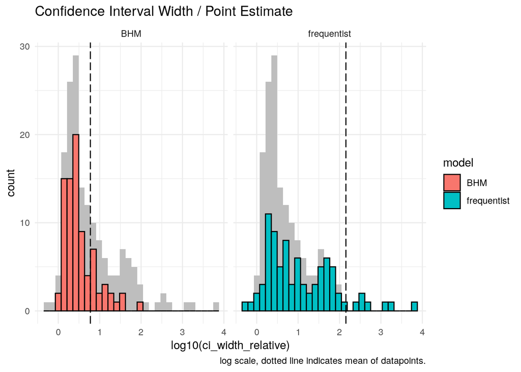

```r
comp_plot_df_width <- bhm_simmed_draws %>%
  filter(n_rhat_issues == 0) %>%
  filter(divergent < 10) %>%
  filter(j == 1) %>%
  mutate(ci_width = abs(conf.high - conf.low),
         ci_width_relative = ci_width / abs(true_term)) %>%
  group_by(model) %>%
  mutate(mean_ci_width_rel = log10(mean(ci_width_relative)))


comp_plot_shadow <- comp_plot_df_width %>%
  ungroup() %>%
  select(-model)

comp_plot_df_width %>%
  ggplot(aes(x = log10(ci_width_relative),
             fill = model)) +
  geom_histogram(data = comp_plot_shadow,
                 fill = "grey") +
  geom_histogram(colour = "black") +
  facet_wrap(~model) +
  theme_minimal() +
  geom_vline(aes(xintercept = mean_ci_width_rel),
             linetype = "longdash") +
  labs(title = "Confidence Interval Width / Point Estimate",
       caption = "log scale, dotted line indicates mean of datapoints.")
```

It seems like weak IV’s crazy large confidence intervals are cropping up in the no pooling model giving us widths 10,000 times larger than their point estimates. On the other hand, the BHM tends to keep things calm with only one draw with a ratio of 100.

Finally, we can plot the density of the squared errors on log scale:

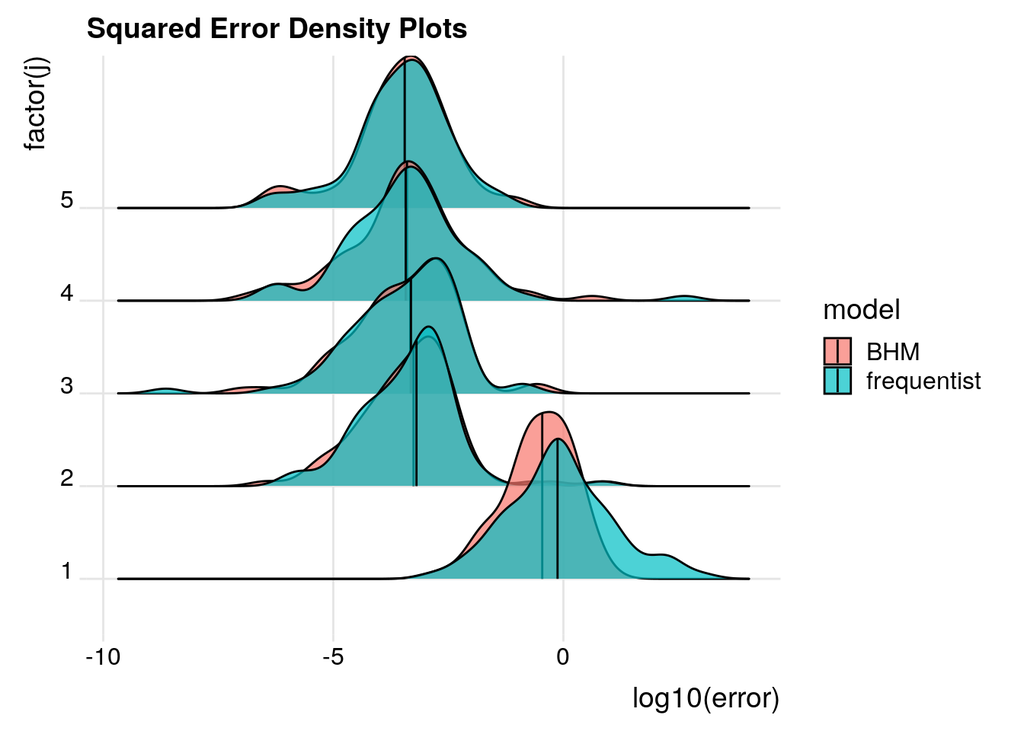

```r
library(ggridges)
hist_error_sq <- bhm_simmed_draws %>%
  filter(n_rhat_issues == 0,
         divergent < 10) %>%
  mutate(error = (true_term - estimate)^2)


hist_error_sq %>%
  ggplot(aes(x = log10(error),
             fill = model,
             y = factor(j))) +
  geom_density_ridges(alpha = 0.7,quantile_lines = TRUE,
                      quantiles = 2
                      ) +
  theme_ridges() +
  labs(title = "Squared Error Density Plots")
```

# Conclusion

We’ve seen how Bayesian hierarchical models offer a nice way to overcome weak instrument issues provided we can exploit information from stronger instruments. I’m a big fan of shrinking IV estimates in general - we know the that the IV estimator is biased and has relatively poor asympotic efficiency compared to its OLS cousin so adding priors and introducing shrinkage is pretty much a free lunch. We improve finite sample performance and in the limit the prior weight tends to 0 anyway.

Chamberlain and Imbens actually had a fully Bayesian solution similar to ours in [1996](https://www.nber.org/papers/t0204) - so they only beat us by 23 years! The final, published, paper linked in the intro isn’t fully Bayesian which is a shame - with stan this is pretty easy to do nowadays as we’ve seen.